# Italian NUTS2 Regional Analysis

IS Pekerti

2025-12-12

## Load Required Libraries

```r
# Install packages if needed
required_packages <- c("sf", "tidyverse", "tmap", "viridis", "knitr", "kableExtra")

for(pkg in required_packages) {
  if(!require(pkg, character.only = TRUE)) {
    install.packages(pkg)
    library(pkg, character.only = TRUE)
  }
}
```

## Load and Prepare Data

```r
# Load shapefile
shp_path <- "C:/Users/satya/OneDrive - Politecnico di Milano/Joint Folder - Pekerti & Fratesi/shapefiles/nuts2_it.shp"
italy_nuts2 <- st_read(shp_path)
# Load STATA dataset (CSV)
stata_path <- "C:/Users/satya/OneDrive - Politecnico di Milano/Joint Folder - Pekerti & Fratesi/cardiff_periodabroad/cardiff_project/analysis/output/descstat_selectvar.csv"
regional_data <- read_csv(stata_path)

# Display the first few rows
cat("### Shapefile structure:\n")
```

```
## ### Shapefile structure:
```

```r
head(italy_nuts2) %>%
  st_drop_geometry() %>%
  kable() %>%
  kable_styling(bootstrap_options = c("striped", "hover", "condensed"))
```

| NUTS_ID | LEVL_CODE | CNTR_CODE | NAME_LATN | NUTS_NAME | MOUNT_TYPE | URBN_TYPE | COAST_TYPE | FID |
| --- | --- | --- | --- | --- | --- | --- | --- | --- |
| ITC1 | 2 | IT | Piemonte | Piemonte | 0 | 0 | 0 | ITC1 |
| ITC2 | 2 | IT | Valle d’Aosta/Vallée d’Aoste | Valle d’Aosta/Vallée d’Aoste | 0 | 0 | 0 | ITC2 |
| ITC3 | 2 | IT | Liguria | Liguria | 0 | 0 | 0 | ITC3 |
| ITG2 | 2 | IT | Sardegna | Sardegna | 0 | 0 | 0 | ITG2 |
| ITH1 | 2 | IT | Provincia Autonoma di Bolzano/Bozen | Provincia Autonoma di Bolzano/Bozen | 0 | 0 | 0 | ITH1 |
| ITH2 | 2 | IT | Provincia Autonoma di Trento | Provincia Autonoma di Trento | 0 | 0 | 0 | ITH2 |

```r
cat("\n### Regional data structure:\n")
```

```
##
## ### Regional data structure:
```

```r
head(regional_data) %>%
  kable() %>%
  kable_styling(bootstrap_options = c("striped", "hover", "condensed"))
```

| reg | econ_adequacy_rev | emp_labourforce | trust_general | trust_neighbour | trust_stranger | rely_relatives | rely_friends | rely_neighbors | neighbourhood_walksafe | neigbourhood_druguser | neigbourhood_drugdealer | neigbourhood_vandal | empatt_equality |
| --- | --- | --- | --- | --- | --- | --- | --- | --- | --- | --- | --- | --- | --- |
| 10 | 2.620592 | 74.41029 | 26.56650 | 2.199940 | 0.8299503 | 55.43543 | 76.00650 | 70.96404 | 2.775453 | 0.3143609 | 0.3113765 | 0.6806703 | 2.777335 |
| 20 | 2.613976 | 74.90480 | 31.94796 | 2.382540 | 1.0070457 | 58.47737 | 81.94556 | 75.66422 | 3.169541 | 0.2006869 | 0.1555777 | 0.4306965 | 2.745614 |
| 30 | 2.704657 | 72.43458 | 27.39805 | 2.186424 | 0.8795682 | 54.49538 | 75.56139 | 66.26014 | 2.622209 | 0.4014786 | 0.4330172 | 0.7496145 | 2.802824 |
| 41 | 2.781129 | 73.42615 | 38.26221 | 2.446900 | 1.0669758 | 60.49898 | 79.69026 | 73.19276 | 2.790151 | 0.3237354 | 0.2649230 | 0.5933457 | 2.676965 |
| 42 | 2.762611 | 72.59457 | 40.17025 | 2.381469 | 1.0404278 | 56.41528 | 77.60225 | 73.76840 | 3.018642 | 0.2215179 | 0.2421297 | 0.5021508 | 2.787482 |
| 50 | 2.680390 | 71.95329 | 30.66823 | 2.247850 | 0.9218438 | 56.42121 | 77.27608 | 69.28928 | 2.616678 | 0.3334467 | 0.2956499 | 0.5810086 | 2.745056 |

## Create Linking Variable

The `reg` variable in the STATA dataset uses ISTAT region codes, which need to be mapped to NUTS2 IDs.

```r
# Create mapping between ISTAT codes (reg) and NUTS2 IDs
region_mapping <- tibble(
  reg = c(10, 20, 30, 41, 42, 50, 60, 70, 80, 90, 100, 110, 120, 130, 140, 150, 160, 170, 180, 190, 200),
  NUTS_ID = c("ITC1", "ITC2", "ITC3", "ITH1", "ITH2", "ITH3", "ITH4", "ITH5",
              "ITI1", "ITI2", "ITI3", "ITI4", "ITF1", "ITF2", "ITF3", "ITF5",
              "ITF6", "ITF4", "ITG1", "ITG2", "ITC4"),
  region_name = c("Piemonte", "Valle d'Aosta/Vallée d'Aoste", "Liguria",
                  "Provincia Autonoma di Bolzano/Bozen", "Provincia Autonoma di Trento",
                  "Veneto", "Friuli-Venezia Giulia", "Emilia-Romagna", "Toscana",
                  "Umbria", "Marche", "Lazio", "Abruzzo", "Molise", "Campania",
                  "Basilicata", "Calabria", "Puglia", "Sicilia", "Sardegna", "Lombardia")
)

# Join regional data with mapping
regional_data_mapped <- regional_data %>%
  left_join(region_mapping, by = "reg")

# Join with shapefile
italy_map_data <- italy_nuts2 %>%
  left_join(regional_data_mapped, by = "NUTS_ID")

# Display merged data
cat("### Merged dataset preview:\n")
```

```
## ### Merged dataset preview:
```

```r
italy_map_data %>%
  st_drop_geometry() %>%
  select(NUTS_ID, NUTS_NAME, reg, econ_adequacy_rev, emp_labourforce, trust_general) %>%
  head(10) %>%
  kable() %>%
  kable_styling(bootstrap_options = c("striped", "hover", "condensed"))
```

| NUTS_ID | NUTS_NAME | reg | econ_adequacy_rev | emp_labourforce | trust_general |
| --- | --- | --- | --- | --- | --- |
| ITC1 | Piemonte | 10 | 2.620592 | 74.41029 | 26.56650 |
| ITC2 | Valle d’Aosta/Vallée d’Aoste | 20 | 2.613976 | 74.90480 | 31.94796 |
| ITC3 | Liguria | 30 | 2.704657 | 72.43458 | 27.39805 |
| ITG2 | Sardegna | 190 | 2.584653 | 62.02648 | 12.24739 |
| ITH1 | Provincia Autonoma di Bolzano/Bozen | 41 | 2.781129 | 73.42615 | 38.26221 |
| ITH2 | Provincia Autonoma di Trento | 42 | 2.762611 | 72.59457 | 40.17025 |
| ITC4 | Lombardia | 200 | 2.622387 | 70.31306 | 30.82118 |
| ITF1 | Abruzzo | 120 | 2.621644 | 70.93607 | 27.59564 |
| ITF2 | Molise | 130 | 2.616784 | 69.41275 | 23.10611 |
| ITF3 | Campania | 140 | 2.647467 | 69.79913 | 18.73887 |

## Note on Variable Scales and Classification

**Important**: The variables displayed are **continuous regional averages** derived from individual-level ordinal responses. While the original survey questions used ordinal scales (e.g., 0-3 or 1-4), the regional aggregation creates continuous measures.

**Actual Regional Data Ranges:** - **Economic Adequacy**: Original scale 1-4, regional averages range from ~2.58 to ~2.78 - **Trust in Neighbors**: Original scale 0-3, regional averages range from ~1.87 to ~2.45 - **Trust in Strangers**: Original scale 0-3, regional averages range from ~0.59 to ~1.07 - **Walking Safety**: Original scale 0-4, regional averages range from ~2.39 to ~3.17 - **Neighborhood Problems**: Original scale 0-3, regional averages are relatively low (~0.15 to ~0.93) - **Employment Equality Attitudes**: Original scale 0-3, regional averages range from ~2.61 to ~2.84

**Map Classification Method:** All maps use **quantile classification** with 5 classes, which divides the data into five groups with equal numbers of regions. This classification method maximizes the visual distinction between regions by showing the relative position of each region within the actual data distribution, rather than using the theoretical scale ranges. The legend values show the actual data ranges for each quantile.

## Summary Statistics

```r
# Summary of key variables
summary_stats <- regional_data_mapped %>%
  select(-reg, -NUTS_ID, -region_name) %>%
  summary()

print(summary_stats)
```

```
##  econ_adequacy_rev emp_labourforce trust_general   trust_neighbour
##  Min.   :2.585     Min.   :62.03   Min.   :12.25   Min.   :1.877
##  1st Qu.:2.622     1st Qu.:69.41   1st Qu.:23.83   1st Qu.:2.100
##  Median :2.643     Median :71.28   Median :27.60   Median :2.151
##  Mean   :2.660     Mean   :70.49   Mean   :27.36   Mean   :2.167
##  3rd Qu.:2.705     3rd Qu.:72.93   3rd Qu.:30.67   3rd Qu.:2.224
##  Max.   :2.781     Max.   :75.90   Max.   :40.17   Max.   :2.447
##  trust_stranger   rely_relatives   rely_friends   rely_neighbors
##  Min.   :0.5917   Min.   :49.94   Min.   :67.50   Min.   :58.86
##  1st Qu.:0.7764   1st Qu.:55.44   1st Qu.:75.56   1st Qu.:66.31
##  Median :0.8505   Median :58.21   Median :76.90   Median :69.29
##  Mean   :0.8491   Mean   :59.57   Mean   :77.15   Mean   :69.31
##  3rd Qu.:0.9106   3rd Qu.:62.70   3rd Qu.:79.69   3rd Qu.:72.15
##  Max.   :1.0670   Max.   :79.08   Max.   :85.78   Max.   :78.04
##  neighbourhood_walksafe neigbourhood_druguser neigbourhood_drugdealer
##  Min.   :2.398          Min.   :0.1732        Min.   :0.1498
##  1st Qu.:2.635          1st Qu.:0.2256        1st Qu.:0.2244
##  Median :2.742          Median :0.3206        Median :0.2956
##  Mean   :2.745          Mean   :0.3051        Mean   :0.2922
##  3rd Qu.:2.832          3rd Qu.:0.3532        3rd Qu.:0.3653
##  Max.   :3.170          Max.   :0.4545        Max.   :0.4330
##  neigbourhood_vandal empatt_equality
##  Min.   :0.4193      Min.   :2.619
##  1st Qu.:0.5126      1st Qu.:2.712
##  Median :0.5810      Median :2.746
##  Mean   :0.6038      Mean   :2.750
##  3rd Qu.:0.6807      3rd Qu.:2.787
##  Max.   :0.9286      Max.   :2.839
```

## Maps: Economic and Employment Indicators

### Economic Adequacy

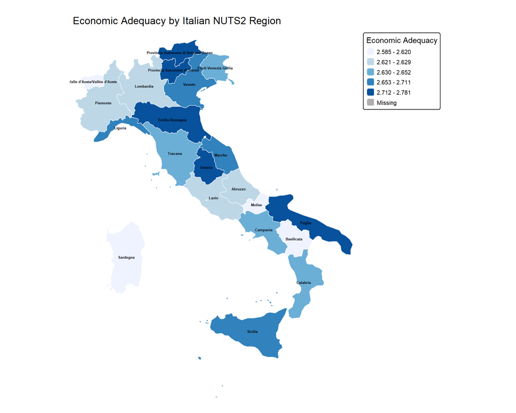

```r
tm_shape(italy_map_data) +
  tm_polygons("econ_adequacy_rev",
              title = "Economic Adequacy",
              palette = "Blues",
              style = "quantile",
              n = 5,
              border.col = "white",
              border.alpha = 0.5) +
  tm_layout(main.title = "Economic Adequacy by Italian NUTS2 Region",
            main.title.size = 1.2,
            legend.outside = TRUE,
            legend.outside.position = "right",
            legend.format = list(digits = 2),
            frame = FALSE) +
  tm_text("NUTS_NAME", size = 0.4, col = "black", fontface = "bold")
```

### Employment in Labour Force

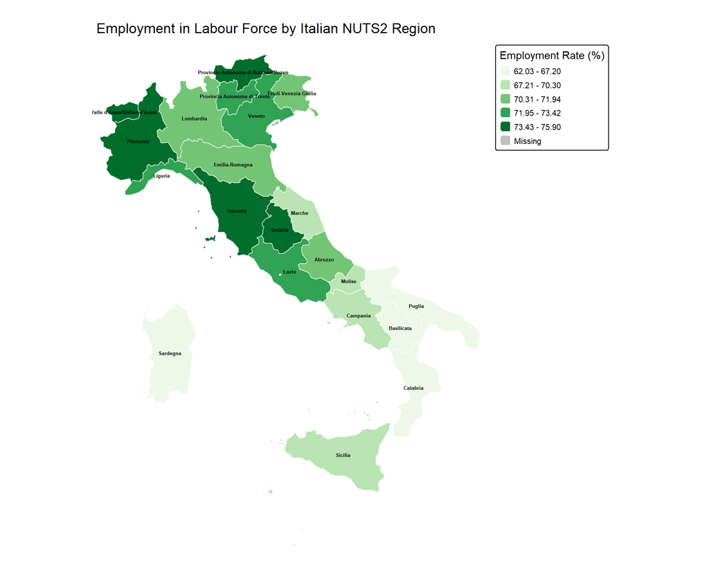

```r
tm_shape(italy_map_data) +
  tm_polygons("emp_labourforce",
              title = "Employment Rate (%)",
              palette = "Greens",
              style = "quantile",
              n = 5,
              border.col = "white",
              border.alpha = 0.5) +
  tm_layout(main.title = "Employment in Labour Force by Italian NUTS2 Region",
            main.title.size = 1.2,
            legend.outside = TRUE,
            legend.outside.position = "right",
            frame = FALSE) +
  tm_text("NUTS_NAME", size = 0.4, col = "black", fontface = "bold")
```

## Maps: Trust and Social Capital

### General Trust

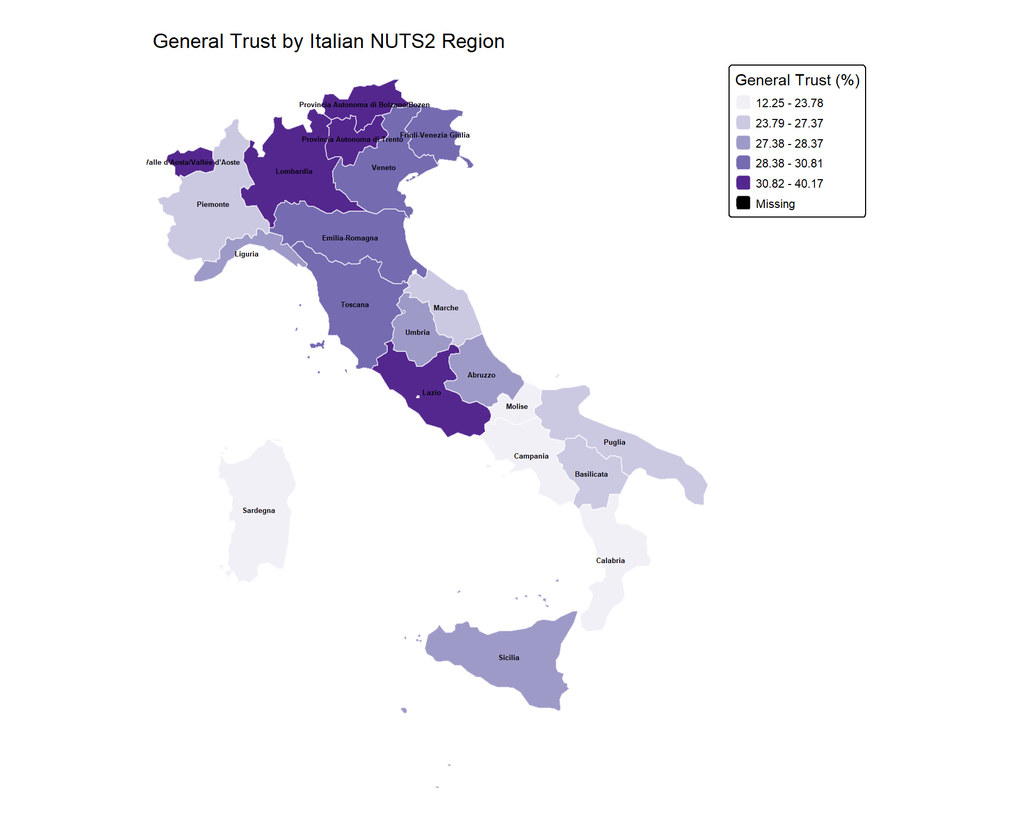

```r
tm_shape(italy_map_data) +
  tm_polygons("trust_general",
              title = "General Trust (%)",
              palette = "Purples",
              style = "quantile",
              n = 5,
              border.col = "white",
              border.alpha = 0.5) +
  tm_layout(main.title = "General Trust by Italian NUTS2 Region",
            main.title.size = 1.2,
            legend.outside = TRUE,
            legend.outside.position = "right",
            legend.format = list(digits = 1),
            frame = FALSE) +
  tm_text("NUTS_NAME", size = 0.4, col = "black", fontface = "bold")
```

### Trust in Neighbors vs Strangers

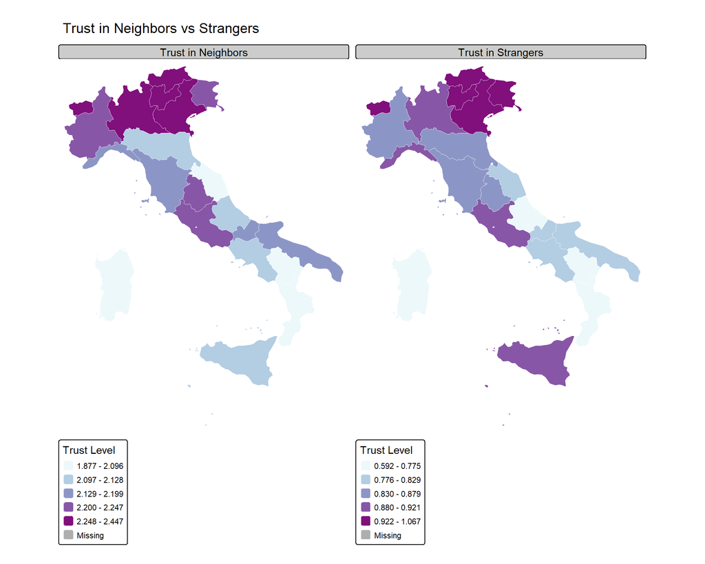

```r
# Create a faceted map comparing trust in neighbors vs strangers
trust_maps <- tm_shape(italy_map_data) +
  tm_polygons(c("trust_neighbour", "trust_stranger"),
              title = c("Trust Level", "Trust Level"),
              palette = list("BuPu", "OrRd"),
              style = "quantile",
              n = 5,
              border.col = "white",
              border.alpha = 0.5) +
  tm_layout(main.title = "Trust in Neighbors vs Strangers",
            main.title.size = 1.2,
            legend.outside = TRUE,
            legend.format = list(digits = 2),
            panel.labels = c("Trust in Neighbors", "Trust in Strangers"),
            frame = FALSE) +
  tm_facets(ncol = 2)

trust_maps
```

## Maps: Social Networks

### Reliance on Social Networks

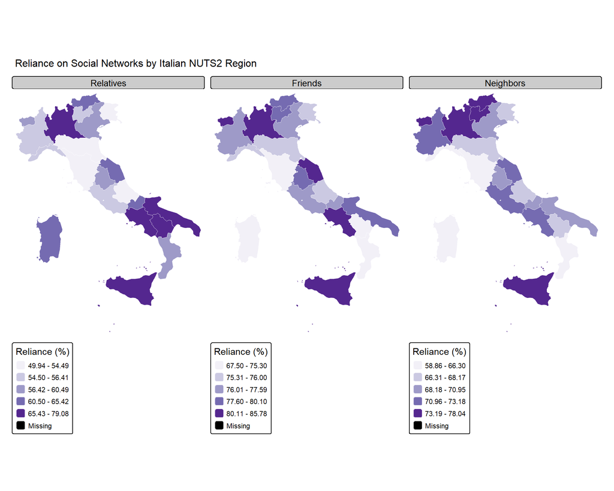

```r
# Create faceted map for reliance on different social groups
tm_shape(italy_map_data) +
  tm_polygons(c("rely_relatives", "rely_friends", "rely_neighbors"),
              title = "Reliance (%)",
              palette = "Purples",
              style = "quantile",
              n = 5,
              border.col = "white",
              border.alpha = 0.5) +
  tm_layout(main.title = "Reliance on Social Networks by Italian NUTS2 Region",
            main.title.size = 1.0,
            legend.outside = TRUE,
            panel.labels = c("Relatives", "Friends", "Neighbors"),
            frame = FALSE) +
  tm_facets(ncol = 3)
```

## Maps: Neighborhood Safety and Problems

### Walking Safety in Neighborhood

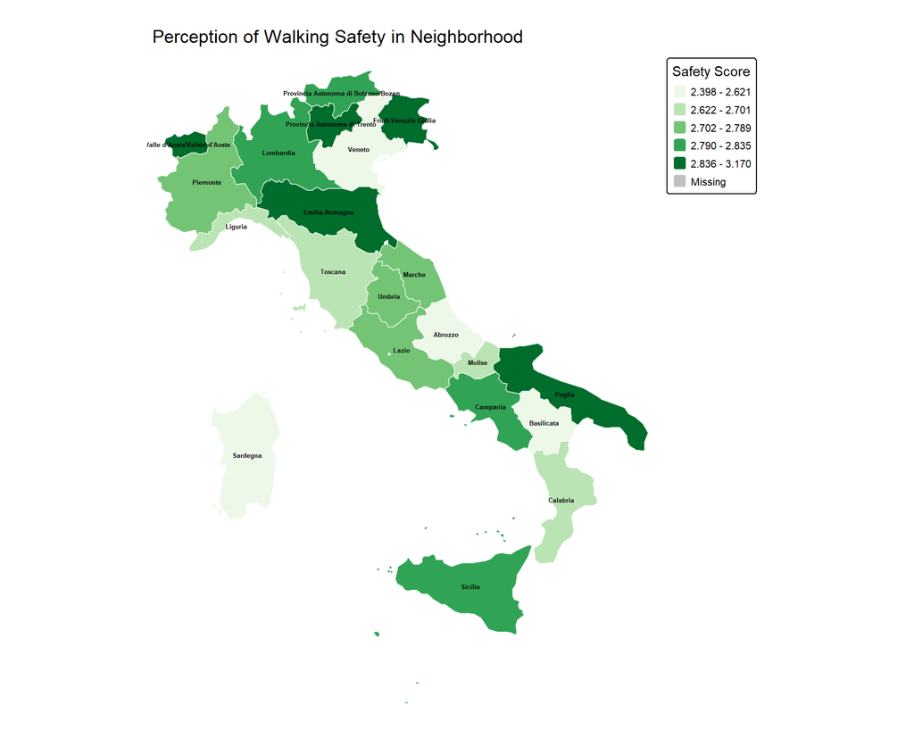

```r
tm_shape(italy_map_data) +
  tm_polygons("neighbourhood_walksafe",
              title = "Safety Score",
              palette = "Greens",
              style = "quantile",
              n = 5,
              border.col = "white",
              border.alpha = 0.5) +
  tm_layout(main.title = "Perception of Walking Safety in Neighborhood",
            main.title.size = 1.2,
            legend.outside = TRUE,
            legend.outside.position = "right",
            legend.format = list(digits = 2),
            frame = FALSE) +
  tm_text("NUTS_NAME", size = 0.4, col = "black", fontface = "bold")
```

### Neighborhood Problems

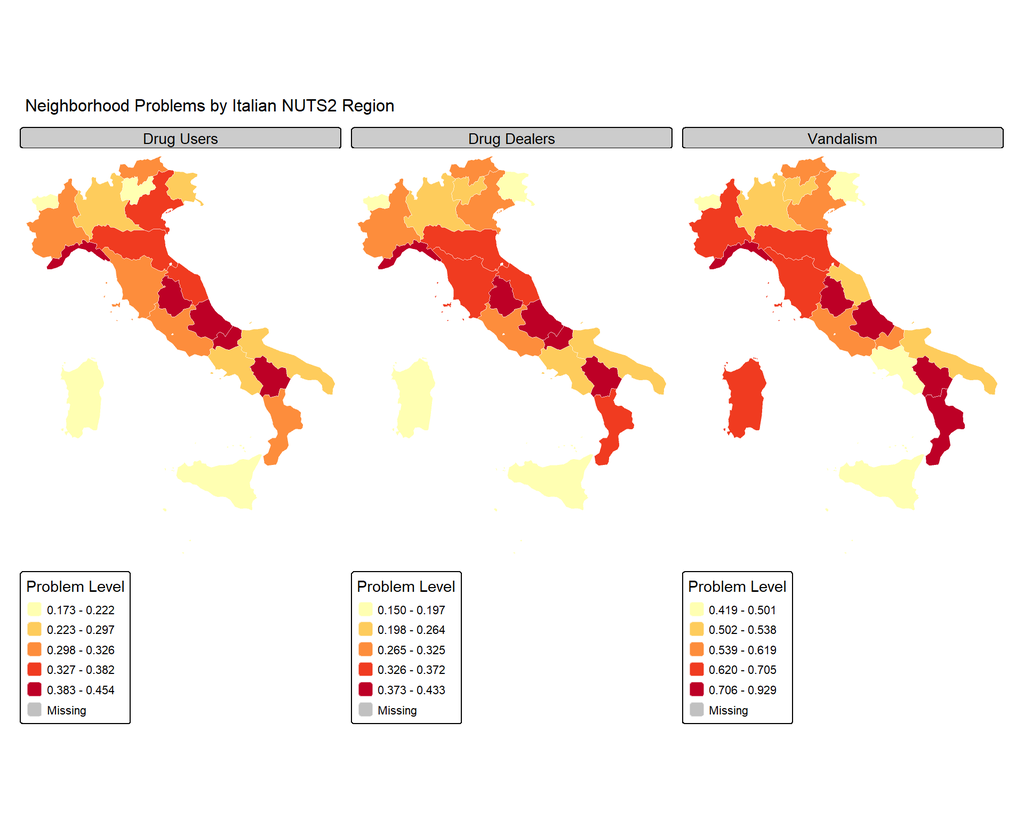

```r
# Create faceted map for neighborhood problems
tm_shape(italy_map_data) +
  tm_polygons(c("neigbourhood_druguser", "neigbourhood_drugdealer", "neigbourhood_vandal"),
              title = "Problem Level",
              palette = "YlOrRd",
              style = "quantile",
              n = 5,
              border.col = "white",
              border.alpha = 0.5) +
  tm_layout(main.title = "Neighborhood Problems by Italian NUTS2 Region",
            main.title.size = 1.0,
            legend.outside = TRUE,
            legend.format = list(digits = 2),
            panel.labels = c("Drug Users", "Drug Dealers", "Vandalism"),
            frame = FALSE) +
  tm_facets(ncol = 3)
```

## Maps: Employment Attitudes

### Employment Equality Attitudes

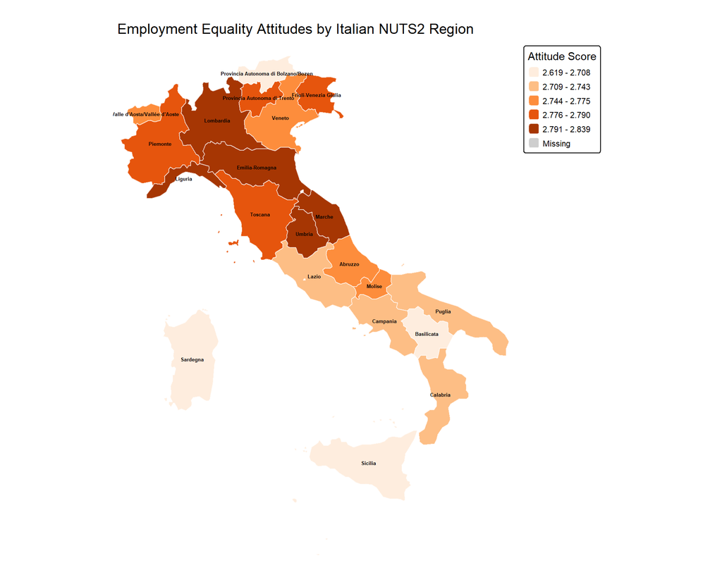

```r
tm_shape(italy_map_data) +
  tm_polygons("empatt_equality",
              title = "Attitude Score",
              palette = "Oranges",
              style = "quantile",
              n = 5,
              border.col = "white",
              border.alpha = 0.5) +
  tm_layout(main.title = "Employment Equality Attitudes by Italian NUTS2 Region",
            main.title.size = 1.2,
            legend.outside = TRUE,
            legend.outside.position = "right",
            legend.format = list(digits = 2),
            frame = FALSE) +
  tm_text("NUTS_NAME", size = 0.4, col = "black", fontface = "bold")
```

## Interactive Map: Economic Adequacy

For exploration, here’s an interactive version of the economic adequacy map:

```r
tmap_mode("view")

tm_shape(italy_map_data) +
  tm_polygons("econ_adequacy_rev",
              title = "Economic Adequacy",
              palette = "Blues",
              style = "quantile",
              n = 5,
              border.col = "white",
              id = "NUTS_NAME",
              popup.vars = c("Region" = "NUTS_NAME",
                            "Economic Adequacy" = "econ_adequacy_rev",
                            "Employment Rate (%)" = "emp_labourforce",
                            "General Trust (%)" = "trust_general")) +
  tm_layout(main.title = "Interactive Map: Economic Adequacy",
            legend.format = list(digits = 2))
```

[interactive chart not shown]

```r
# Reset to plot mode for subsequent static maps
tmap_mode("plot")
```

## Correlation Analysis

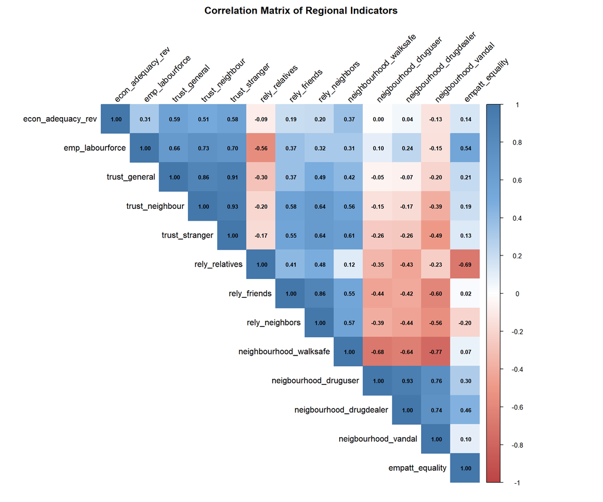

```r
# Create correlation matrix
library(corrplot)

cor_data <- italy_map_data %>%
  st_drop_geometry() %>%
  select(econ_adequacy_rev, emp_labourforce, trust_general, trust_neighbour,
         trust_stranger, rely_relatives, rely_friends, rely_neighbors,
         neighbourhood_walksafe, neigbourhood_druguser, neigbourhood_drugdealer,
         neigbourhood_vandal, empatt_equality) %>%
  na.omit()

cor_matrix <- cor(cor_data)

corrplot(cor_matrix, method = "color", type = "upper",
         tl.col = "black", tl.srt = 45,
         addCoef.col = "black", number.cex = 0.7,
         col = colorRampPalette(c("#BB4444", "#EE9988", "#FFFFFF", "#77AADD", "#4477AA"))(200),
         title = "Correlation Matrix of Regional Indicators",
         mar = c(0,0,2,0))
```

## Regional Rankings

```r
# Create rankings for key indicators
rankings <- italy_map_data %>%
  st_drop_geometry() %>%
  select(NUTS_NAME, econ_adequacy_rev, emp_labourforce, trust_general) %>%
  arrange(desc(econ_adequacy_rev)) %>%
  mutate(
    econ_rank = row_number(),
    emp_rank = rank(-emp_labourforce),
    trust_rank = rank(-trust_general)
  ) %>%
  select(NUTS_NAME, econ_adequacy_rev, econ_rank, emp_labourforce, emp_rank,
         trust_general, trust_rank)

rankings %>%
  kable(digits = 2,
        col.names = c("Region", "Economic Adequacy", "Rank",
                      "Employment Rate", "Rank", "General Trust", "Rank"),
        caption = "Regional Rankings by Key Indicators") %>%
  kable_styling(bootstrap_options = c("striped", "hover", "condensed"),
                full_width = FALSE)
```

Regional Rankings by Key Indicators

| Region | Economic Adequacy | Rank | Employment Rate | Rank | General Trust | Rank |
| --- | --- | --- | --- | --- | --- | --- |
| Provincia Autonoma di Bolzano/Bozen | 2.78 | 1 | 73.43 | 5 | 38.26 | 2 |
| Provincia Autonoma di Trento | 2.76 | 2 | 72.59 | 7 | 40.17 | 1 |
| Puglia | 2.73 | 3 | 65.38 | 18 | 23.79 | 17 |
| Emilia-Romagna | 2.72 | 4 | 71.47 | 10 | 29.84 | 7 |
| Umbria | 2.71 | 5 | 75.90 | 1 | 27.38 | 13 |
| Liguria | 2.70 | 6 | 72.43 | 8 | 27.40 | 12 |
| Veneto | 2.68 | 7 | 71.95 | 9 | 30.67 | 6 |
| Marche | 2.66 | 8 | 70.22 | 14 | 24.42 | 15 |
| Sicilia | 2.65 | 9 | 67.21 | 17 | 27.85 | 10 |
| Campania | 2.65 | 10 | 69.80 | 15 | 18.74 | 20 |
| Friuli-Venezia Giulia | 2.64 | 11 | 71.28 | 11 | 28.70 | 8 |
| Toscana | 2.63 | 12 | 74.83 | 3 | 28.38 | 9 |
| Calabria | 2.63 | 13 | 65.11 | 19 | 21.83 | 19 |
| Lombardia | 2.62 | 14 | 70.31 | 13 | 30.82 | 5 |
| Lazio | 2.62 | 15 | 72.93 | 6 | 31.02 | 4 |
| Abruzzo | 2.62 | 16 | 70.94 | 12 | 27.60 | 11 |
| Piemonte | 2.62 | 17 | 74.41 | 4 | 26.57 | 14 |
| Molise | 2.62 | 18 | 69.41 | 16 | 23.11 | 18 |
| Valle d’Aosta/Vallée d’Aoste | 2.61 | 19 | 74.90 | 2 | 31.95 | 3 |
| Basilicata | 2.61 | 20 | 63.72 | 20 | 23.83 | 16 |
| Sardegna | 2.58 | 21 | 62.03 | 21 | 12.25 | 21 |